# White Wine quality Analysis

This is an attempt to explore the various properties that affect the quality score of White Wine.

Set Working Directory and Load the Input csv.

```r
setwd("C:/udacity/EDA_USING_R/project")
whiteWineData<-read.csv("wineQualityWhites.csv")
#qplot(quality, data = whiteWineData, fill = color, binwidth = 1) +
#    scale_x_continuous(breaks = seq(3,10,1), lim = c(3,10)) +
#    scale_y_sqrt()
```

### Summary of the Data

```r
summary(whiteWineData)
```

```
##        X        fixed.acidity    volatile.acidity  citric.acid
##  Min.   :   1   Min.   : 3.800   Min.   :0.0800   Min.   :0.0000
##  1st Qu.:1225   1st Qu.: 6.300   1st Qu.:0.2100   1st Qu.:0.2700
##  Median :2450   Median : 6.800   Median :0.2600   Median :0.3200
##  Mean   :2450   Mean   : 6.855   Mean   :0.2782   Mean   :0.3342
##  3rd Qu.:3674   3rd Qu.: 7.300   3rd Qu.:0.3200   3rd Qu.:0.3900
##  Max.   :4898   Max.   :14.200   Max.   :1.1000   Max.   :1.6600
##  residual.sugar     chlorides       free.sulfur.dioxide
##  Min.   : 0.600   Min.   :0.00900   Min.   :  2.00
##  1st Qu.: 1.700   1st Qu.:0.03600   1st Qu.: 23.00
##  Median : 5.200   Median :0.04300   Median : 34.00
##  Mean   : 6.391   Mean   :0.04577   Mean   : 35.31
##  3rd Qu.: 9.900   3rd Qu.:0.05000   3rd Qu.: 46.00
##  Max.   :65.800   Max.   :0.34600   Max.   :289.00
##  total.sulfur.dioxide    density             pH          sulphates
##  Min.   :  9.0        Min.   :0.9871   Min.   :2.720   Min.   :0.2200
##  1st Qu.:108.0        1st Qu.:0.9917   1st Qu.:3.090   1st Qu.:0.4100
##  Median :134.0        Median :0.9937   Median :3.180   Median :0.4700
##  Mean   :138.4        Mean   :0.9940   Mean   :3.188   Mean   :0.4898
##  3rd Qu.:167.0        3rd Qu.:0.9961   3rd Qu.:3.280   3rd Qu.:0.5500
##  Max.   :440.0        Max.   :1.0390   Max.   :3.820   Max.   :1.0800
##     alcohol         quality
##  Min.   : 8.00   Min.   :3.000
##  1st Qu.: 9.50   1st Qu.:5.000
##  Median :10.40   Median :6.000
##  Mean   :10.51   Mean   :5.878
##  3rd Qu.:11.40   3rd Qu.:6.000
##  Max.   :14.20   Max.   :9.000
```

```r
#whiteWineData$color<-"white"
```

From the summary , some of the median values are lesser than the Mean values. Possible outliers or data skew. Also the Max value of free sulfur.dioxide and residual.sugar are way beyond the other values. Otherwise most of them seem like normal distributions.But lets plot to verify .

```r
str(whiteWineData)
```

```
## 'data.frame':    4898 obs. of  13 variables:
##  $ X                   : int  1 2 3 4 5 6 7 8 9 10 ...
##  $ fixed.acidity       : num  7 6.3 8.1 7.2 7.2 8.1 6.2 7 6.3 8.1 ...
##  $ volatile.acidity    : num  0.27 0.3 0.28 0.23 0.23 0.28 0.32 0.27 0.3 0.22 ...
##  $ citric.acid         : num  0.36 0.34 0.4 0.32 0.32 0.4 0.16 0.36 0.34 0.43 ...
##  $ residual.sugar      : num  20.7 1.6 6.9 8.5 8.5 6.9 7 20.7 1.6 1.5 ...
##  $ chlorides           : num  0.045 0.049 0.05 0.058 0.058 0.05 0.045 0.045 0.049 0.044 ...
##  $ free.sulfur.dioxide : num  45 14 30 47 47 30 30 45 14 28 ...
##  $ total.sulfur.dioxide: num  170 132 97 186 186 97 136 170 132 129 ...
##  $ density             : num  1.001 0.994 0.995 0.996 0.996 ...
##  $ pH                  : num  3 3.3 3.26 3.19 3.19 3.26 3.18 3 3.3 3.22 ...
##  $ sulphates           : num  0.45 0.49 0.44 0.4 0.4 0.44 0.47 0.45 0.49 0.45 ...
##  $ alcohol             : num  8.8 9.5 10.1 9.9 9.9 10.1 9.6 8.8 9.5 11 ...
##  $ quality             : int  6 6 6 6 6 6 6 6 6 6 ...
```

```r
names(whiteWineData)
```

```
##  [1] "X"                    "fixed.acidity"        "volatile.acidity"
##  [4] "citric.acid"          "residual.sugar"       "chlorides"
##  [7] "free.sulfur.dioxide"  "total.sulfur.dioxide" "density"
## [10] "pH"                   "sulphates"            "alcohol"
## [13] "quality"
```

### Points of interest that will be explored

1. Which input variables have high correlation with the output variable quality
2. Do input variables have any relation or are they independent (for e.g impact of pH on alcohol, residual sugars on density etc.,)

I want to start by checking the correlation between Quality and other inputs to see if there are any strong candidates that we can start our analysis with.

```r
cor(x=whiteWineData[,2:12], y=whiteWineData$quality,method="pearson")
```

```
##                              [,1]
## fixed.acidity        -0.113662831
## volatile.acidity     -0.194722969
## citric.acid          -0.009209091
## residual.sugar       -0.097576829
## chlorides            -0.209934411
## free.sulfur.dioxide   0.008158067
## total.sulfur.dioxide -0.174737218
## density              -0.307123313
## pH                    0.099427246
## sulphates             0.053677877
## alcohol               0.435574715
```

From the values ,none of them have a very strong correlation but we can see that alcohol has a good positive correlation.pH and sulphates have a positive but week correlation. Density seems to have a relatively high negative correlation followed by chlorides , volatile.acidity and total.sulfur.dioxide

Below are a few utility functions that will be used later during the analysis.

## Utility functions

Below function f_qualitygroup is used to return the dataset after grouping by the grouping variable. Although we need only to group by quality as part of this analysis , we can use any variable passed as grouping_var and input_var

```r
library(dplyr)
library(lazyeval)

f_qualitygroup <- function(data,grouping_var,input_var){

 data.quality_group<-data %>%
  group_by_(grouping_var) %>%
  summarise_(group_mean=interp(~mean(input_var),input_var=as.name(input_var)),
            group_median=interp(~median(input_var),input_var=as.name(input_var)),
            n=~n()
            )
 return (data.quality_group)

}
```

Function to draw scatterplot with a few options needed for the analysis. It includes the Linear regression plot as well as the mean as the hline

```r
f_drawscatter <- function(dataset, x, y,  opts=NULL) {
  ggplot(dataset, aes_string(x = x, y = y)) +
   geom_jitter(alpha = 1/5) +
   geom_smooth(method = 'lm')+
    geom_hline(yintercept = mean(dataset[,y]),linetype='longdash',alpha=0.5,
               color="blue")
}
```

```r
f_drawbox <- function(dataset, x, y,  opts=NULL) {
  ggplot(dataset, aes_string(x = x, y = y)) +
   geom_boxplot(alpha = 1/5) +
   geom_smooth(method = 'lm')+
    geom_hline(yintercept = mean(dataset[,y]),linetype='longdash',alpha=0.5,
               color="blue")
}
```

Let us analyze each variable starting with distribution of Quality

## Univariate and BiVariate analysis

### 1. Quality

```r
summary(whiteWineData$quality)
```

```
##    Min. 1st Qu.  Median    Mean 3rd Qu.    Max.
##   3.000   5.000   6.000   5.878   6.000   9.000
```

```r
table(whiteWineData$quality)
```

```
##
##    3    4    5    6    7    8    9
##   20  163 1457 2198  880  175    5
```

Let us plot a histogram.

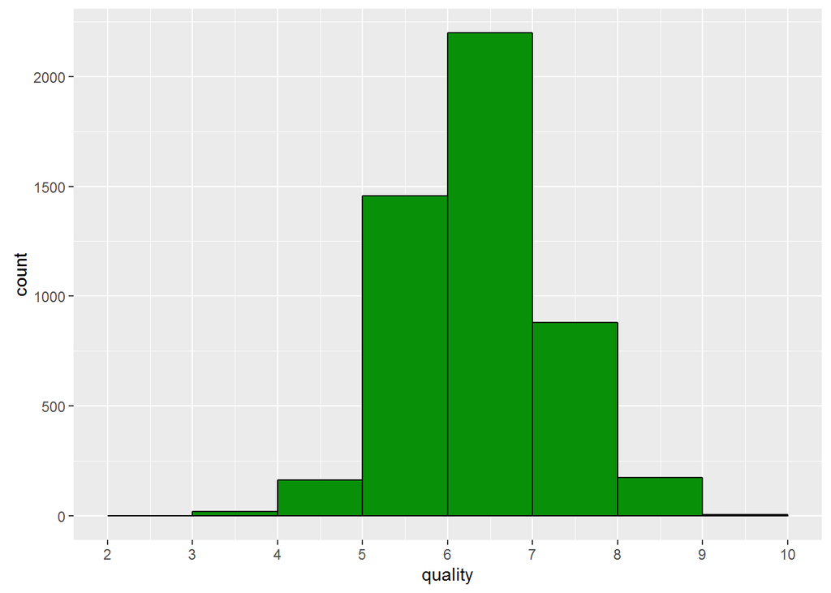

```r
quality_plot=ggplot(data=whiteWineData,aes(x=quality))
quality_plot+geom_histogram(binwidth=1,color=I('black'),fill=I('#099009'))+
  scale_x_continuous(breaks = seq(2,10,1), lim = c(2,10))
```

From the plot , we can see that lot of wines have quality between 5 to 8 and there is none below 3 and above 9.

### 2. Alcohol

```r
summary(whiteWineData$alcohol)
```

```
##    Min. 1st Qu.  Median    Mean 3rd Qu.    Max.
##    8.00    9.50   10.40   10.51   11.40   14.20
```

Mean is slightly higher than Median and Max value is 14.2.There must be some skew in the data.

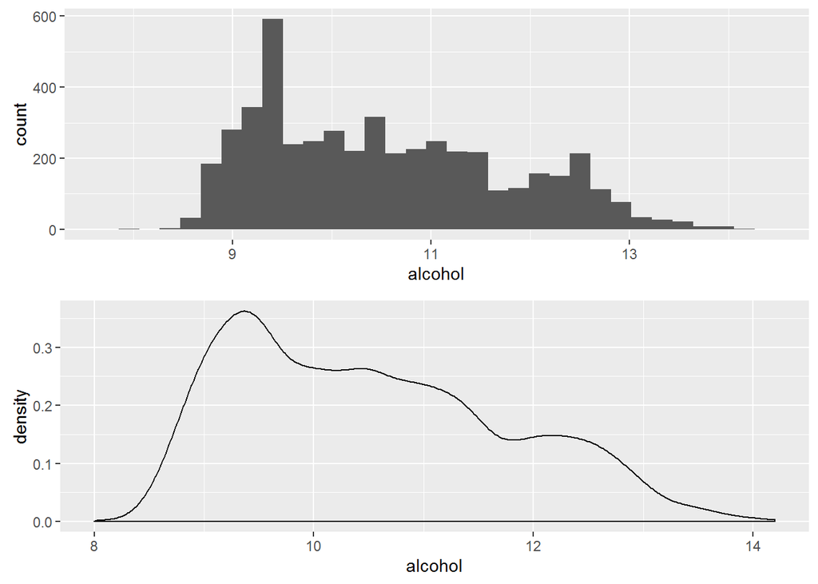

```r
alcohol_plot=ggplot(data=whiteWineData,aes(x=alcohol))
alc_hist<-alcohol_plot+geom_histogram()
alc_dens<-alcohol_plot+geom_density()
grid.arrange(alc_hist,alc_dens,nrow=2)
```

The dataset looks a little positively skewed. Alcohol levels are between 8 and 14.

Let us study the affect of alcohol on quality .

Let us put the grouping utility function to use on quality and alcohol

### 3. Quality vs Alcohol

‘##’ quality_alcohol_group contains the mean and median values of the alcohol content in each ’##’quality group

```r
whiteWineData.quality_alcohol_group<-f_qualitygroup(whiteWineData,"quality"
                                                    ,"alcohol")
summary(whiteWineData$alcohol)
```

```
##    Min. 1st Qu.  Median    Mean 3rd Qu.    Max.
##    8.00    9.50   10.40   10.51   11.40   14.20
```

```r
head(whiteWineData.quality_alcohol_group)
```

```
## Source: local data frame [6 x 4]
##
##   quality group_mean group_median     n
##     (int)      (dbl)        (dbl) (int)
## 1       3   10.34500        10.45    20
## 2       4   10.15245        10.10   163
## 3       5    9.80884         9.50  1457
## 4       6   10.57537        10.50  2198
## 5       7   11.36794        11.40   880
## 6       8   11.63600        12.00   175
```

From the above grouping , we can see that the wines that have quality score of 6,7,8 have mean alcohol levels greater than the overall mean alcohol level of 10.5 . Interestingly the ones that have quality score of 3,4 have mean alcohol values close to the overall Mean and greater than the ones with quality score of 5. There may be other factors affecting the score in case of these which shadowed alcohol quantity.

Let us draw plots that depicts these above numbers.

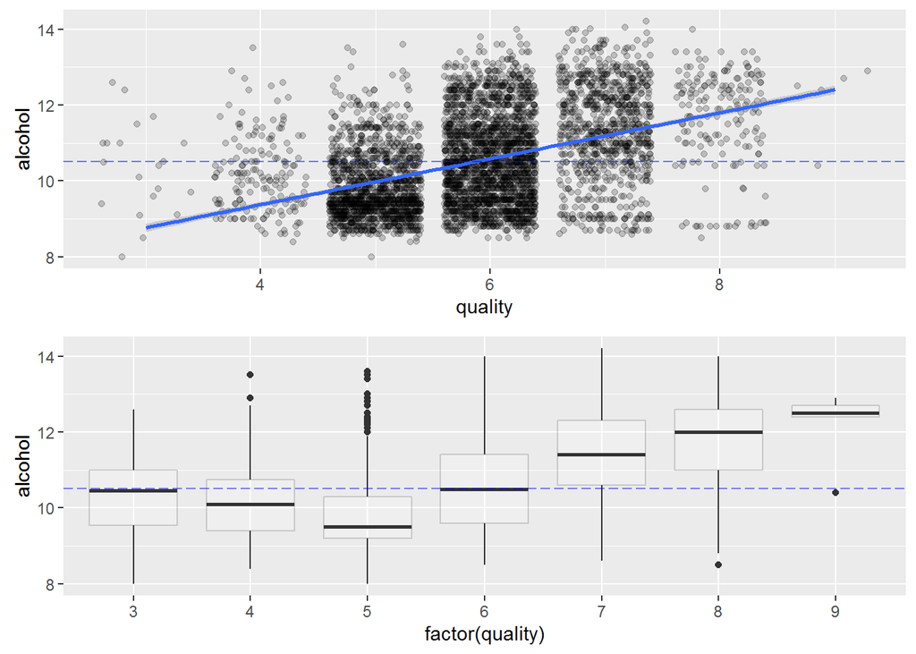

```r
qual_alc_scatterplot <-f_drawscatter(whiteWineData,"quality","alcohol")
qual_alc_boxplot <-f_drawbox(whiteWineData,"factor(quality)","alcohol")
grid.arrange(qual_alc_scatterplot,qual_alc_boxplot)
```

From the plots, we can see that there is a linear positive pattern between quality and alcohol level but it is also evident that there are other factors alongside alcohol that might have affected the quality.

### 4. Density

Let us focus on density vs quality .

```r
summary(whiteWineData$density)
```

```
##    Min. 1st Qu.  Median    Mean 3rd Qu.    Max.
##  0.9871  0.9917  0.9937  0.9940  0.9961  1.0390
```

Mean is slightly higher than median and probably due to the data skew

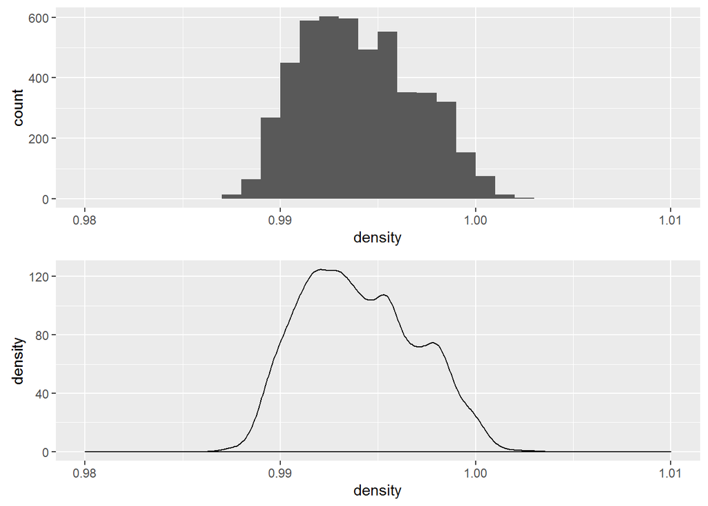

```r
density_plot=ggplot(data=whiteWineData,aes(x=density))+
  scale_x_continuous(limits=c(0.98,1.01))
dens_hist<-density_plot+geom_histogram()
winedens_dens<-density_plot+geom_density()
grid.arrange(dens_hist,winedens_dens,nrow=2)
```

There are two odd peaks and data seems to be a little right skewed.

### 5 .Density vs Quality

‘##’ similar to alcohol, let us create a variable to hold mean and median values of density for ’##’each quality group.

```r
whiteWineData.quality_density_group<-f_qualitygroup(whiteWineData,"quality",
                                                    "density")
summary(whiteWineData$density)
```

```
##    Min. 1st Qu.  Median    Mean 3rd Qu.    Max.
##  0.9871  0.9917  0.9937  0.9940  0.9961  1.0390
```

```r
head(whiteWineData.quality_density_group)
```

```
## Source: local data frame [6 x 4]
##
##   quality group_mean group_median     n
##     (int)      (dbl)        (dbl) (int)
## 1       3  0.9948840     0.994425    20
## 2       4  0.9942767     0.994100   163
## 3       5  0.9952626     0.995300  1457
## 4       6  0.9939613     0.993660  2198
## 5       7  0.9924524     0.991760   880
## 6       8  0.9922359     0.991640   175
```

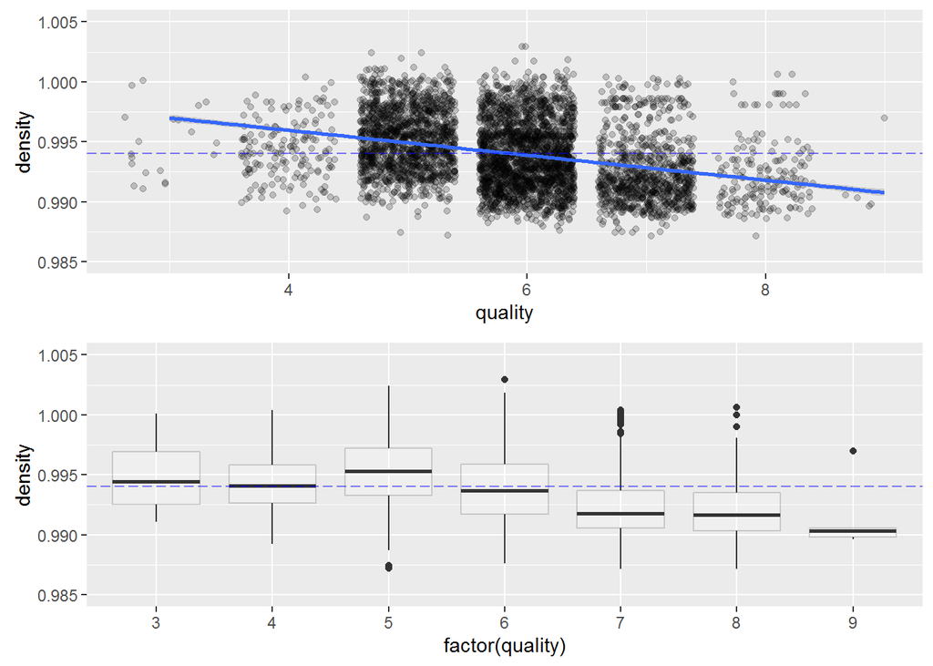

```r
qual_den_scatterplot <-f_drawscatter(whiteWineData,"quality","density")+
  scale_y_continuous(limits=c(0.985,1.005))
qual_den_boxplot <-f_drawbox(whiteWineData,"factor(quality)","density")+
  scale_y_continuous(limits=c(0.985,1.005))
grid.arrange(qual_den_scatterplot,qual_den_boxplot)
```

From the plots , we can see that the ones with high quality rating have density lower than the mean overall density across samples and the quality increased with a decrease in density.

Let us check the effect of chlorides on quality

### 6 . Chlorides

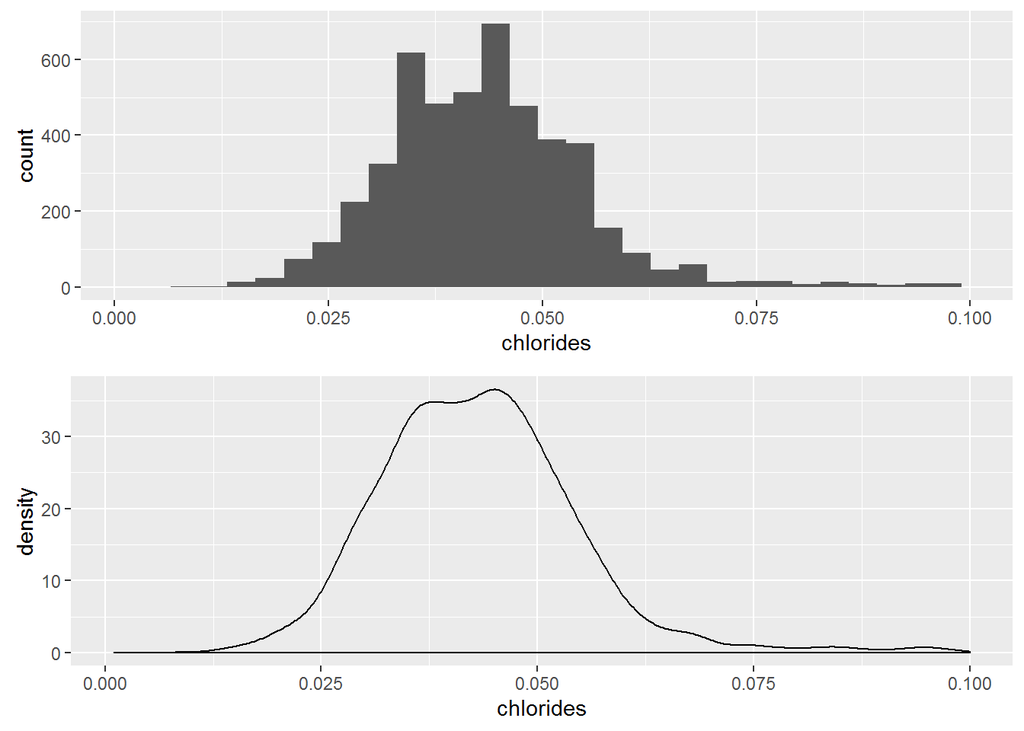

```r
chlorides_plot=ggplot(data=whiteWineData,aes(x=chlorides))+scale_x_continuous(limits=c(0.001,0.1))
chlor_hist<-chlorides_plot+geom_histogram()
chlor_dens<-chlorides_plot+geom_density()
grid.arrange(chlor_hist,chlor_dens,nrow=2)
```

Seems like a normal distribution except for the twin peaks.

### 7 . Quality vs Chlorides

```r
whiteWineData.quality_chlorides_group<-f_qualitygroup(whiteWineData,"quality",
                                                      "chlorides")
summary(whiteWineData$chlorides)
```

```
##    Min. 1st Qu.  Median    Mean 3rd Qu.    Max.
## 0.00900 0.03600 0.04300 0.04577 0.05000 0.34600
```

```r
head(whiteWineData.quality_chlorides_group)
```

```
## Source: local data frame [6 x 4]
##
##   quality group_mean group_median     n
##     (int)      (dbl)        (dbl) (int)
## 1       3 0.05430000        0.041    20
## 2       4 0.05009816        0.046   163
## 3       5 0.05154633        0.047  1457
## 4       6 0.04521747        0.043  2198
## 5       7 0.03819091        0.037   880
## 6       8 0.03831429        0.036   175
```

The ones with high quality score seem to have less amount of chlorides compared to the low quality score ones

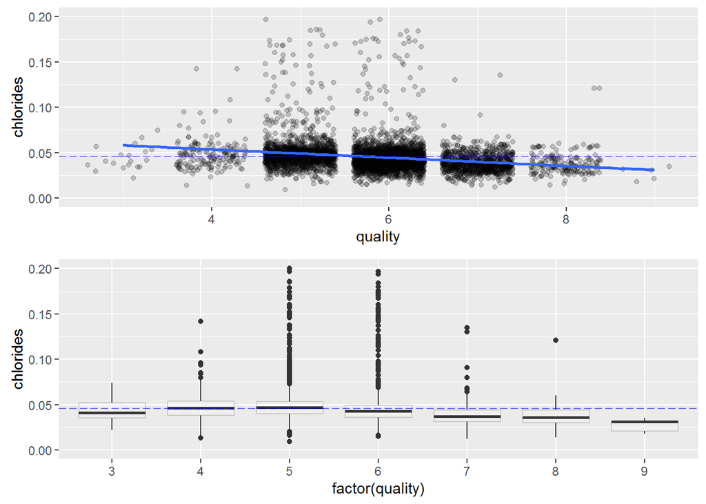

```r
qual_chl_scatterplot <-f_drawscatter(whiteWineData,"quality","chlorides")+
  scale_y_continuous(limits=c(0,0.2))
qual_chl_boxplot <-f_drawbox(whiteWineData,"factor(quality)","chlorides")+
  scale_y_continuous(limits=c(0,0.2))
grid.arrange(qual_chl_scatterplot,qual_chl_boxplot)
```

From the plots , we can see that the ones with high quality rating have chlorides lower than the mean overall chlorides across samples.

Let us also check the relation between total.sulfur.dioxide and quality.

### 8. Total SO2

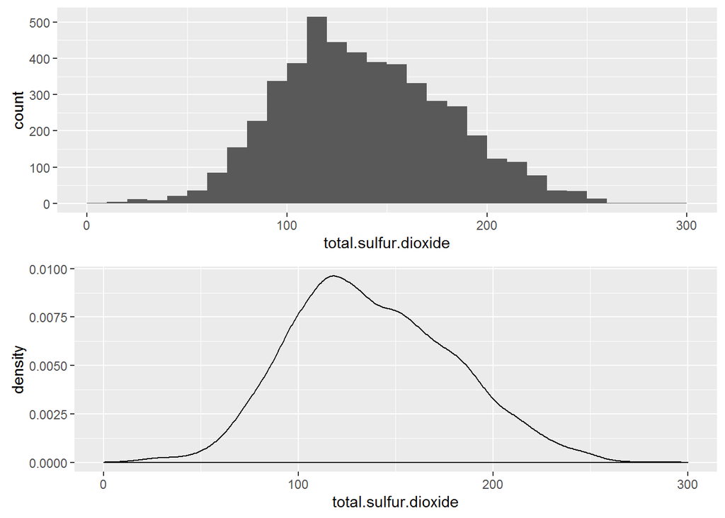

```r
totalso2_plot=ggplot(data=whiteWineData,aes(x=total.sulfur.dioxide))+
  scale_x_continuous(limits=c(0,300))
totalso2_hist<-totalso2_plot+geom_histogram()
totalso2_dens<-totalso2_plot+geom_density()
grid.arrange(totalso2_hist,totalso2_dens,nrow=2)
```

Seems like a normal but a slight right skew in the disribution.

### 9. Total SO2 vs Quality

```r
whiteWineData.quality_totalso2_group<-f_qualitygroup(whiteWineData,
                                                     "quality","total.sulfur.dioxide")
summary(whiteWineData$total.sulfur.dioxide)
```

```
##    Min. 1st Qu.  Median    Mean 3rd Qu.    Max.
##     9.0   108.0   134.0   138.4   167.0   440.0
```

```r
head(whiteWineData.quality_totalso2_group)
```

```
## Source: local data frame [6 x 4]
##
##   quality group_mean group_median     n
##     (int)      (dbl)        (dbl) (int)
## 1       3   170.6000        159.5    20
## 2       4   125.2791        117.0   163
## 3       5   150.9046        151.0  1457
## 4       6   137.0473        132.0  2198
## 5       7   125.1148        122.0   880
## 6       8   126.1657        122.0   175
```

From the numbers , except for the wines with quality score 4 , there is a negative linear relation between quality and total.sulfur.dixoide. Let us plot to confirm.

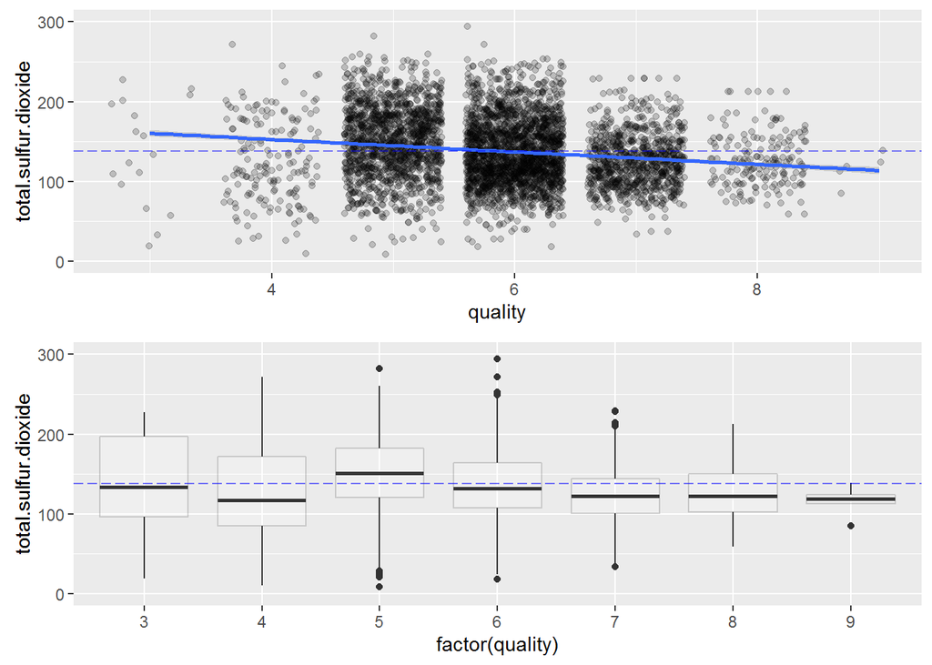

```r
qual_so2_scatterplot <-f_drawscatter(whiteWineData,"quality",
                                    "total.sulfur.dioxide")+
  scale_y_continuous(limits=c(0,300))
qual_so2_boxplot <-f_drawbox(whiteWineData,"factor(quality)",
                             "total.sulfur.dioxide")+
  scale_y_continuous(limits=c(0,300))
grid.arrange(qual_so2_scatterplot,qual_so2_boxplot)
```

total.sulfur.dixode also seems to be less in the high score wines than the ones with a low score.

### 10. residual sugar

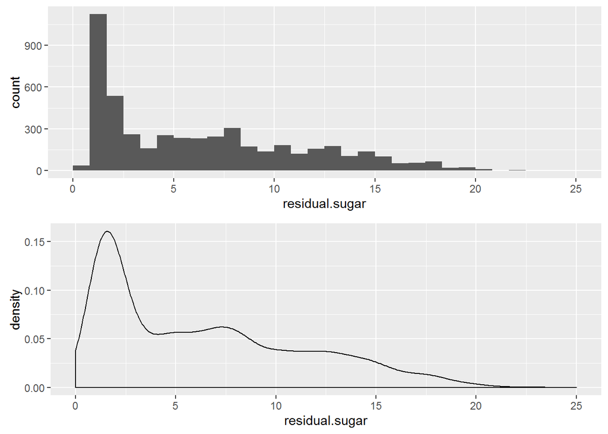

```r
sugar_plot=ggplot(data=whiteWineData,aes(x=residual.sugar))+
  scale_x_continuous(limits=c(0,25))
sugar_hist<-sugar_plot+geom_histogram()
sugar_dens<-sugar_plot+geom_density()
grid.arrange(sugar_hist,sugar_dens,nrow=2)
```

The tail on the right side is long and seems to be right skewed distribution. Lot of them have values between 0 to 5

Let us plot the residual.sugar vs quality plots

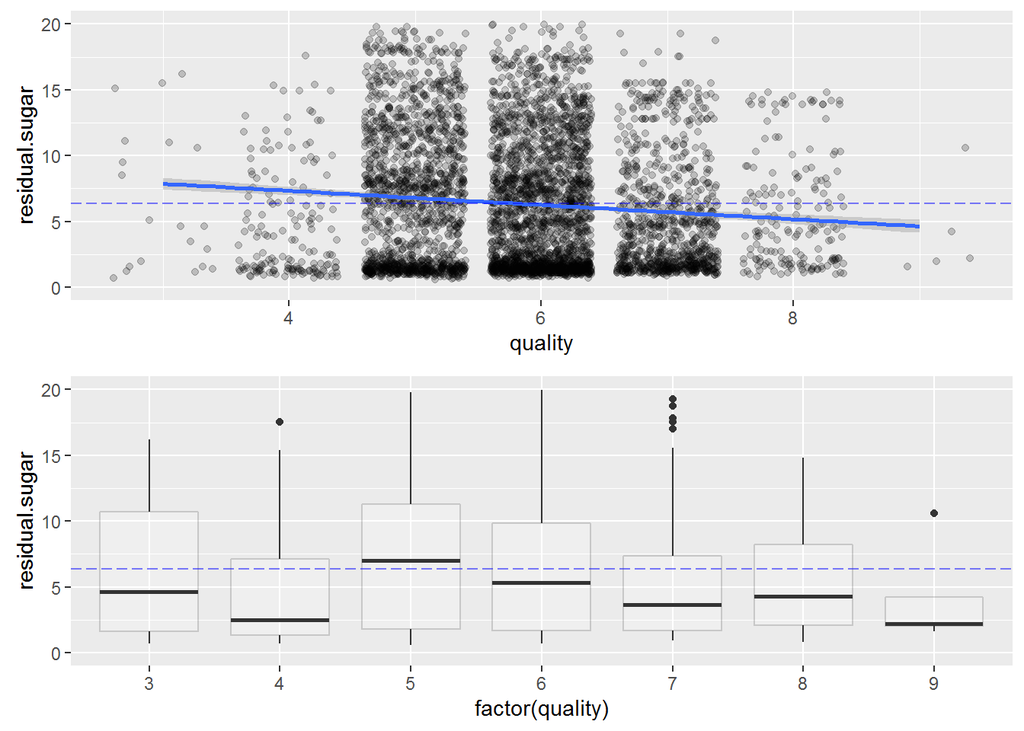

```r
qual_sugar_scatterplot <-f_drawscatter(whiteWineData,"quality","residual.sugar")+
  scale_y_continuous(limits=c(0,20))
qual_sugar_boxplot <-f_drawbox(whiteWineData,"factor(quality)","residual.sugar")+
  scale_y_continuous(limits=c(0,20))
grid.arrange(qual_sugar_scatterplot,qual_sugar_boxplot)
```

residual sugars also seem to have a negative correlation with quality.

Based on the observations till now , alcohol and density seems to have strong correlation with quality . Let us also see which other variables have strong relationship with density and alcohol and choose for our multivariate analysis.

```r
cor(x=whiteWineData[,2:12], y=whiteWineData$density,method="pearson")
```

```
##                             [,1]
## fixed.acidity         0.26533101
## volatile.acidity      0.02711385
## citric.acid           0.14950257
## residual.sugar        0.83896645
## chlorides             0.25721132
## free.sulfur.dioxide   0.29421041
## total.sulfur.dioxide  0.52988132
## density               1.00000000
## pH                   -0.09359149
## sulphates             0.07449315
## alcohol              -0.78013762
```

values show that other than alcohol’s strong negative correlation, residual sugar and total.sulfur.dioxide seem to have a strong positive correlation with density.

```r
cor(x=whiteWineData[,2:12], y=whiteWineData$alcohol,method="pearson")
```

```
##                             [,1]
## fixed.acidity        -0.12088112
## volatile.acidity      0.06771794
## citric.acid          -0.07572873
## residual.sugar       -0.45063122
## chlorides            -0.36018871
## free.sulfur.dioxide  -0.25010394
## total.sulfur.dioxide -0.44889210
## density              -0.78013762
## pH                    0.12143210
## sulphates            -0.01743277
## alcohol               1.00000000
```

For alcohol, there are no strong positive correlation but a lot of negative correlation factors( density and other variables that have strong correlation with density).

## Multivariate Analysis

Let us consider density , alcohol , residual.sugar,total.sulfur.dixoide and chlorides for our multivariate analysis.

Starting with density and alcohol vs quality

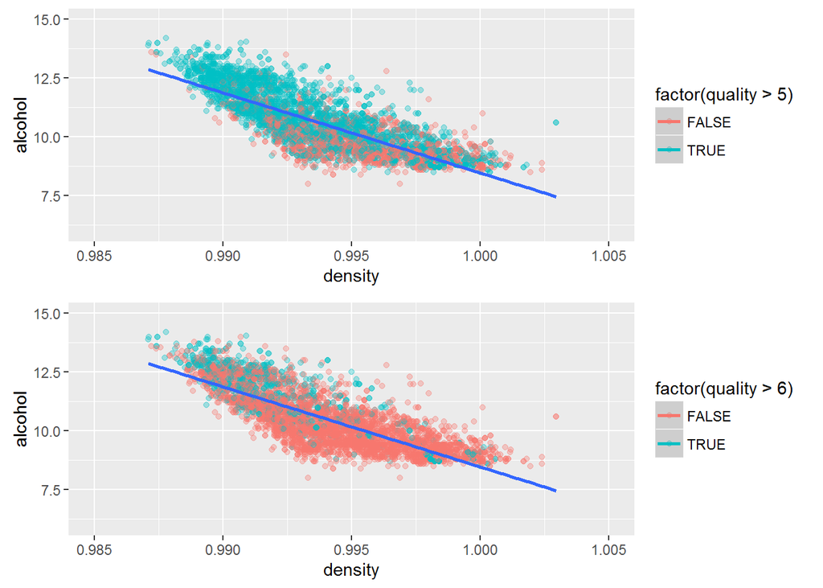

```r
qual_dens_alc_scatplotplus5 <-ggplot(aes(x=density,y=alcohol,color=factor(quality>5)),data=whiteWineData)+
  geom_jitter(alpha=1/3) +
  geom_smooth(method='lm', aes(group = 1))+
  scale_x_continuous(limits=c(0.985,1.005))+
  scale_y_continuous(limits=c(6,15))

qual_dens_alc_scatplotplus6 <-ggplot(aes(x=density,y=alcohol,color=factor(quality>6)),data=whiteWineData)+
  geom_jitter(alpha=1/3) +
  geom_smooth(method='lm', aes(group = 1))+
  scale_x_continuous(limits=c(0.985,1.005))+
  scale_y_continuous(limits=c(6,15))

grid.arrange(qual_dens_alc_scatplotplus5,qual_dens_alc_scatplotplus6)
```

Alcohol and Density have a strong negative correlation. We can see that a lot of wines that have a quality score greater than 6 are at the top left side and the ones less than 6 are concentrated at lower right.

```r
whiteWineData.quality_groups<-whiteWineData%>%
  group_by(quality)%>%
  summarise(mean_alc=mean(alcohol),
            mean_den=mean(density),
            mean_sugar=mean(residual.sugar),
            mean_totalso2=mean(total.sulfur.dioxide),
            mean_chlorides=mean(chlorides),
            mean_pH=mean(pH),
            mean_sulph=mean(sulphates),
            n=n()
            )%>%
  arrange(quality)

head(whiteWineData.quality_groups)
```

```
## Source: local data frame [6 x 9]
##
##   quality mean_alc  mean_den mean_sugar mean_totalso2 mean_chlorides
##     (int)    (dbl)     (dbl)      (dbl)         (dbl)          (dbl)
## 1       3 10.34500 0.9948840   6.392500      170.6000     0.05430000
## 2       4 10.15245 0.9942767   4.628221      125.2791     0.05009816
## 3       5  9.80884 0.9952626   7.334969      150.9046     0.05154633
## 4       6 10.57537 0.9939613   6.441606      137.0473     0.04521747
## 5       7 11.36794 0.9924524   5.186477      125.1148     0.03819091
## 6       8 11.63600 0.9922359   5.671429      126.1657     0.03831429
## Variables not shown: mean_pH (dbl), mean_sulph (dbl), n (int)
```

### Quality vs residual sugar and density

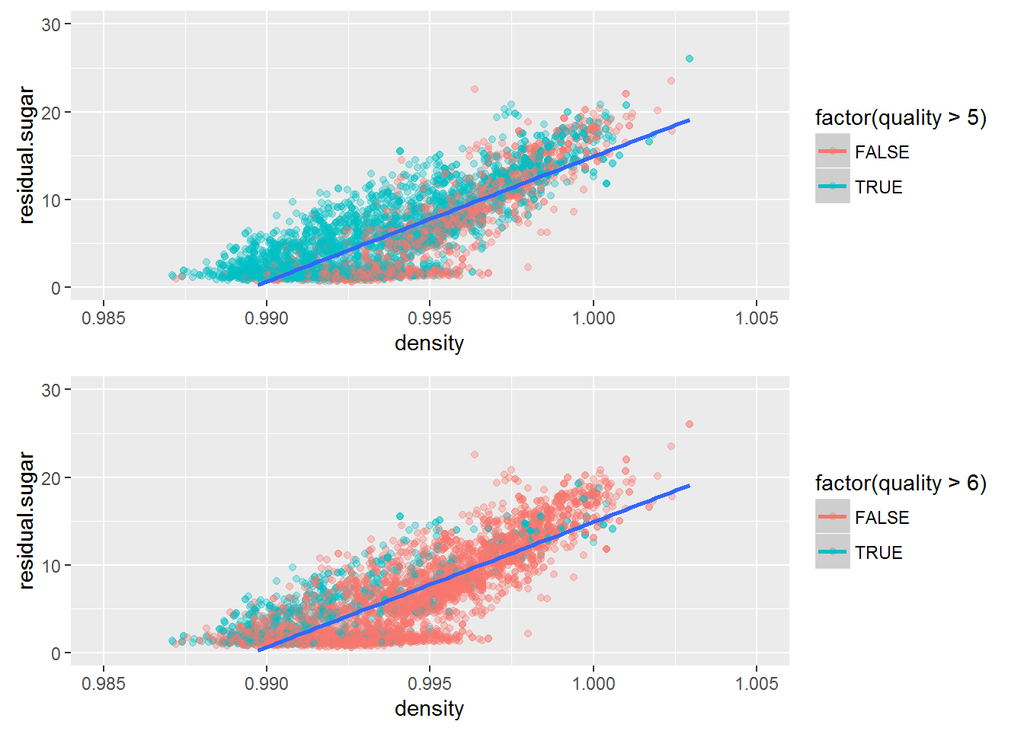

```r
qual_dens_sug_scatplotplus5 <-ggplot(aes(x=density,y=residual.sugar,
                                         color=factor(quality>5)),
                                     data=whiteWineData)+
  geom_jitter(alpha=1/3) +
  geom_smooth(method='lm', aes(group = 1))+
  scale_x_continuous(limits=c(0.985,1.005))+
  scale_y_continuous(limits=c(0,30))

qual_dens_sug_scatplotplus6 <-ggplot(aes(x=density,y=residual.sugar,
                                         color=factor(quality>6)),
                                     data=whiteWineData)+
  geom_jitter(alpha=1/3) +
  geom_smooth(method='lm', aes(group = 1))+
  scale_x_continuous(limits=c(0.985,1.005))+
  scale_y_continuous(limits=c(0,30))

grid.arrange(qual_dens_sug_scatplotplus5,qual_dens_sug_scatplotplus6)
```

From the plot , we can see that the ones that have quality score greater than 6 have low residual sugar and density.The ones that have quality score 5 and 6 are dispersed across the spectrum.

### Quality vs totalso2 and density

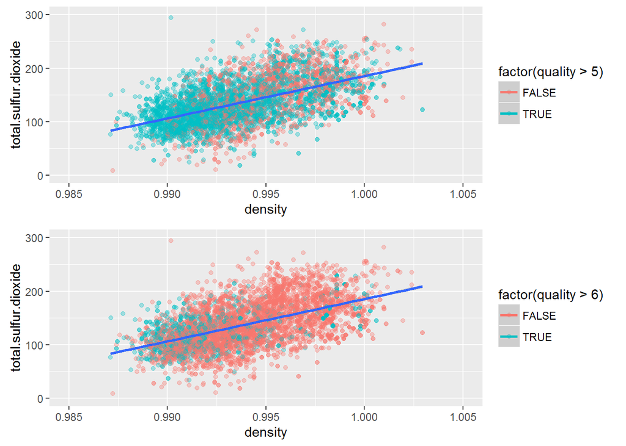

```r
qual_dens_totso2_scatplotplus5 <-ggplot(aes(x=density,y=total.sulfur.dioxide,color=factor(quality>5)),
                                        data=whiteWineData)+
  geom_jitter(alpha=1/3) +
  geom_smooth(method='lm', aes(group = 1))+
  scale_x_continuous(limits=c(0.985,1.005))+
  scale_y_continuous(limits=c(0,300))

qual_dens_totso2_scatplotplus6 <-ggplot(aes(x=density,y=total.sulfur.dioxide,color=factor(quality>6)),
                                        data=whiteWineData)+
  geom_jitter(alpha=1/3) +
  geom_smooth(method='lm', aes(group = 1))+
  scale_x_continuous(limits=c(0.985,1.005))+
  scale_y_continuous(limits=c(0,300))

grid.arrange(qual_dens_totso2_scatplotplus5,qual_dens_totso2_scatplotplus6)
```

This also is inline with the correlation numbers. The ones that have low total.sulfur.dioxide and density have quality rating >6

## Final 3 Plots

1. Quality Univariate
2. Alcohol vs quality and Density vs quality box plots grid
3. Quality vs Alcohol vs Density multivariate

### Final plot1

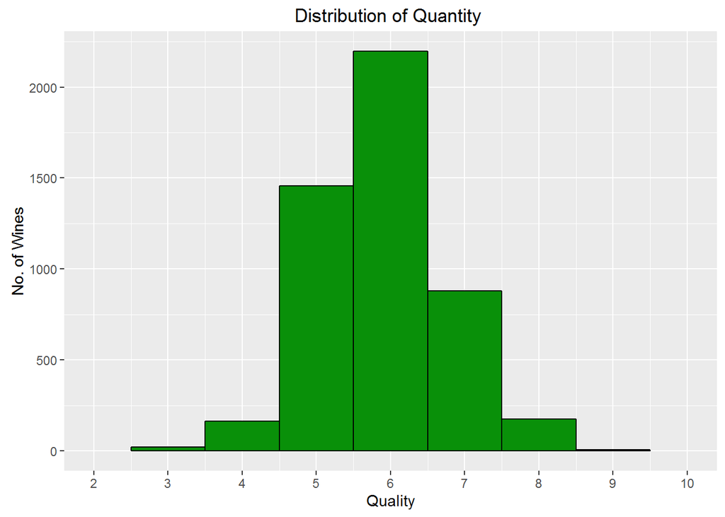

```r
quality_plot_fp1=ggplot(data=whiteWineData,aes(x=quality))
quality_plot_fp1+geom_histogram(binwidth=1,color=I('black'),fill=I('#099009'),origin=-0.5)+
  scale_x_continuous(breaks = seq(2,10,1), lim = c(2,10))+
  xlab("Quality")+
  ylab("No. of Wines")+
  ggtitle("Distribution of Quantity ")
```

Final plot1 Description :

1. Quality has values ranging from 3 to 9
2. Most of the wines have a quality score of 5 and 6 ,6 being highest, very few have the highest of 9 and lowest score of 3.

### Final plot 2

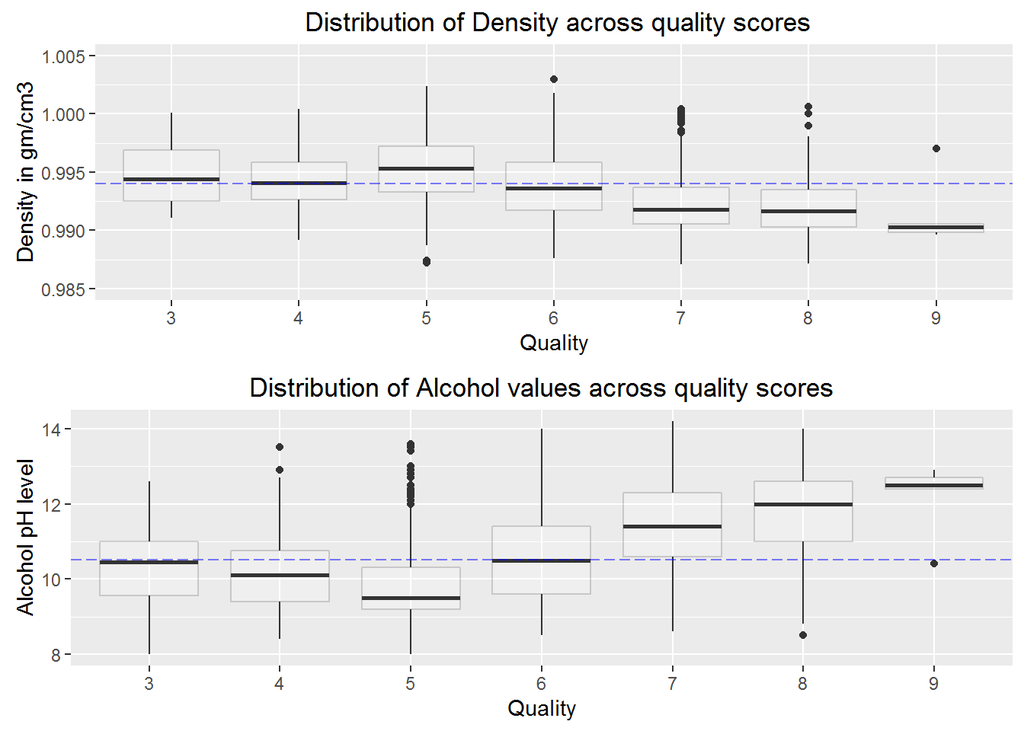

```r
qual_den_fp2 <-f_drawbox(whiteWineData,"factor(quality)","density")+
  scale_y_continuous(limits=c(0.985,1.005))+
  xlab("Quality")+
  ylab("Density in gm/cm3")+
  ggtitle(" Distribution of Density across quality scores")

qual_alc_fp2 <-f_drawbox(whiteWineData,"factor(quality)","alcohol")+
  xlab("Quality")+
  ylab("Alcohol pH level")+
  ggtitle(" Distribution of Alcohol values across quality scores ")

grid.arrange(qual_den_fp2,qual_alc_fp2)
```

### Final plot 3

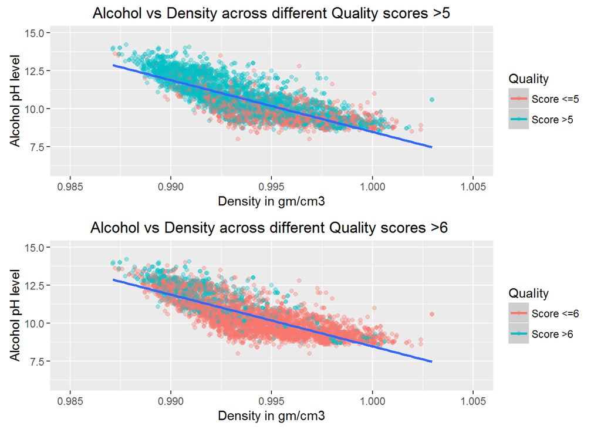

```r
qual_dens_alc_fp3_plus5 <-ggplot(aes(x=density,y=alcohol,
                                     color=factor(quality>5)),
                                 data=whiteWineData)+
  geom_jitter(alpha=1/3) +
  geom_smooth(method='lm', aes(group = 1))+
  scale_x_continuous(limits=c(0.985,1.005))+
  scale_y_continuous(limits=c(6,15))+
  xlab("Density in gm/cm3")+
  ylab("Alcohol pH level")+
  ggtitle("Alcohol vs Density across different Quality scores >5")+
  scale_colour_discrete(name='Quality',
                        labels=c("Score <=5","Score >5"))


qual_dens_alc_fp3_plus6 <-ggplot(aes(x=density,y=alcohol,
                                     color=factor(quality>6)),
                                 data=whiteWineData)+
  geom_jitter(alpha=1/3) +
  geom_smooth(method='lm', aes(group = 1))+
  scale_x_continuous(limits=c(0.985,1.005))+
  scale_y_continuous(limits=c(6,15))+
  xlab("Density in gm/cm3")+
  ylab("Alcohol pH level")+
  ggtitle("Alcohol vs Density across different Quality scores >6 ")+
  scale_colour_discrete(name='Quality',
                        labels=c("Score <=6","Score >6"))

grid.arrange(qual_dens_alc_fp3_plus5,qual_dens_alc_fp3_plus6)
```

Final plot 3 Description :

1. Quality score 6 (which is most common) has dispersed along the density and alcohol axes.
2. But we can clearly see that wines that have quality score greater than 6 have high alcohol content and low density.(except for a few exceptions)

## Reflection:

Although there are trends , there are deviations which I could not explain with the given dataset. For e.g., Density and Alcohol have negative and positive correlation with Quality score in general but wines of Score 3 have greater alcohol content than wines of score 4 and 5. Similarly Wines of score 5 have greater Density than wines of score 3 and 4. I could not find a way to dig deeper to justify these anamolies.

The dataset had wines with quality scores 5 and 6 dominant.Hence we may not be able to use this as a training data to predict wines of very high quality. We may need more data that has details and composition of high quality wines.